[figure not shown]

### **Школа глубокого обучения ФПМИ МФТИ**

### **Базовый поток. Осень 2020**

# **Неделя 1. Библиотека Pandas**

Библиотека `pandas` активно используется в современном data science для работы с данными, которые могут быть представлены в виде таблиц (а это очень, очень большая часть данных)

`pandas` есть в пакете Anaconda, но если вдруг у Вас её по каким-то причинам нет, то можно установить, раскомментировав следующую команду:

```python
!pip install pandas
```

```python
import numpy as np
import pandas as pd #Стандартное сокращение для pandas. Всегда используйте его!
```

# pd.Series

Тип данных pd.Series представляет собой одномерный набор данных. Отсутствующий данные записываются как `np.nan` (в этот день термометр сломался или метеоролог был пьян); они не участвуют в вычислении средних, среднеквадратичных отклонений и т.д.

### Создание

Создадим Series из списка температур

```python
some_list = [1, 3, 5, np.nan, 6, 8]
ser_1 = pd.Series(some_list)
ser_1
```

```
0    1.0
1    3.0
2    5.0
3    NaN
4    6.0
5    8.0
dtype: float64
```

### Индексация

В pd.Series индексация может быть задана пользователем.

```python
# Так же можно в явном виде указать индексы, чтобы потом было более удобно обращаться к элементам
ind = ['1st day', '2nd day', '3rd day', '4th day', '5rd day', '6th day']

ser_2 = pd.Series(some_list, index=ind)
ser_2
```

```
1st day    1.0
2nd day    3.0
3rd day    5.0
4th day    NaN
5rd day    6.0
6th day    8.0
dtype: float64
```

### Обращение к элементу

Обращение непосредственно через индекс:

```python
ser_2['4th day']
```

```
nan
```

### Слайсинг

Почти как обычные питоновские слайсы, только второй конец будет включаться, итерация по индексам.

```python
ser_2['1st day':'4th day']
```

```
1st day    1.0
2nd day    3.0
3rd day    5.0
4th day    NaN
dtype: float64
```

А еще можно дать pd.Series имя, чтобы было совсем красиво

```python
ser_3 = pd.Series(some_list, index=ind, name='Temperature')
ser_3
```

```
1st day    1.0
2nd day    3.0
3rd day    5.0
4th day    NaN
5rd day    6.0
6th day    8.0
Name: Temperature, dtype: float64
```

### Индексирование

С индексами можно работать так же, как и в случае с обычным `list`.

```python
print(ser_3[0])

print('-----------')

print(ser_3[1 : 3])

print('-----------')

print(ser_3[::-1])
```

```
1.0
-----------
2nd day    3.0
3rd day    5.0
Name: Temperature, dtype: float64
-----------
6th day    8.0
5rd day    6.0
4th day    NaN
3rd day    5.0
2nd day    3.0
1st day    1.0
Name: Temperature, dtype: float64
```

### Индексирование pd.Series по условиям

```python
date_range = pd.date_range('20190101', periods=10)
ser_4 = pd.Series(np.random.rand(10), index=date_range)
ser_4
```

```
2019-01-01    0.606373
2019-01-02    0.521666
2019-01-03    0.281361
2019-01-04    0.635221
2019-01-05    0.117266
2019-01-06    0.313540
2019-01-07    0.282567
2019-01-08    0.344874
2019-01-09    0.992079
2019-01-10    0.981786
Freq: D, dtype: float64
```

```python
ser_4 > 0.5
```

```
2019-01-01     True
2019-01-02     True
2019-01-03    False
2019-01-04     True
2019-01-05    False
2019-01-06    False
2019-01-07    False
2019-01-08    False
2019-01-09     True
2019-01-10     True
Freq: D, dtype: bool
```

В качестве индекса можно указать выражение, и нам будут возвращены только те элементы, для которых значение является `True`

```python
ser_4[ser_4 > 0.5]
```

```
2019-01-01    0.606373
2019-01-02    0.521666
2019-01-04    0.635221
2019-01-09    0.992079
2019-01-10    0.981786
dtype: float64
```

Не самая тривиальная логика

```python
ser_4[(ser_4 > 0.6) | (ser_4 < 0.2)]
```

```
2019-01-01    0.606373
2019-01-04    0.635221
2019-01-05    0.117266
2019-01-09    0.992079
2019-01-10    0.981786
dtype: float64
```

### Сортировки

Тип `pd.Series` можно отсортировать как по значениям, так и по индексу.

```python
ser_4.sort_index()
```

```
2019-01-01    0.606373
2019-01-02    0.521666
2019-01-03    0.281361
2019-01-04    0.635221
2019-01-05    0.117266
2019-01-06    0.313540
2019-01-07    0.282567
2019-01-08    0.344874
2019-01-09    0.992079
2019-01-10    0.981786
Freq: D, dtype: float64
```

```python
ser_4.sort_values()
```

```
2019-01-05    0.117266
2019-01-03    0.281361
2019-01-07    0.282567
2019-01-06    0.313540
2019-01-08    0.344874
2019-01-02    0.521666
2019-01-01    0.606373
2019-01-04    0.635221
2019-01-10    0.981786
2019-01-09    0.992079
dtype: float64
```

### Операции с series

Тип `pd.Series` можно модифицировать проще, чем стандартный `list` из Python.

Как это в обычных листах:

```python
a = [1, 2, 3, 4, 5]
b = [x + 100 for x in a]
b
# a + 100 уже не сработает
```

```
[101, 102, 103, 104, 105]
```

```python
ser_4 + 100
```

```
2019-01-01    100.606373
2019-01-02    100.521666
2019-01-03    100.281361
2019-01-04    100.635221
2019-01-05    100.117266
2019-01-06    100.313540
2019-01-07    100.282567
2019-01-08    100.344874
2019-01-09    100.992079
2019-01-10    100.981786
Freq: D, dtype: float64
```

```python
np.exp(ser_4)
```

```
2019-01-01    1.833768
2019-01-02    1.684832
2019-01-03    1.324932
2019-01-04    1.887440
2019-01-05    1.124419
2019-01-06    1.368260
2019-01-07    1.326531
2019-01-08    1.411812
2019-01-09    2.696836
2019-01-10    2.669220
Freq: D, dtype: float64
```

```python
term_1 = pd.Series(np.random.randint(0, 10, 5))
term_2 = pd.Series(np.random.randint(0, 10, 6))

term_1 + term_2
```

```
0    17.0
1     4.0
2    12.0
3     9.0
4    11.0
5     NaN
dtype: float64
```

```python
term_1.shape
```

```
(5,)
```

# pd.DataFrame

Тип данных pd.DataFrame представляет собой двумерную таблицу с данными. Имеет индекс и набор столбцов (возможно, имеющих разные типы). Таблицу можно построить, например, из словаря, значениями в котором являются одномерные наборы данных.

### Создание и основные объекты

```python
# Dataframe можно составить из словаря. Ключ будет соответсовать колонке
some_dict = {'one': pd.Series([1,2,3], index=['a','b','c']),
             'two': pd.Series([1,2,3,4], index=['a','b','c','d']),
             'three': pd.Series([5,6,7,8], index=['a','b','c','d'])}
df = pd.DataFrame(some_dict)
df
```

|  | one | two | three |
| --- | --- | --- | --- |
| a | 1.0 | 1 | 5 |
| b | 2.0 | 2 | 6 |
| c | 3.0 | 3 | 7 |
| d | NaN | 4 | 8 |

```python
#Альтернативно, из списка списков с аргументом columns

some_array = [[1,1,5], [2,2,6], [3,3,7], [np.nan, 4,8]]
df = pd.DataFrame(some_array, index=['a', 'b', 'c', 'd'], columns=['one', 'two', 'three'])
df
```

|  | one | two | three |
| --- | --- | --- | --- |
| a | 1.0 | 1 | 5 |
| b | 2.0 | 2 | 6 |
| c | 3.0 | 3 | 7 |
| d | NaN | 4 | 8 |

```python
df.values
```

```
array([[ 1.,  1.,  5.],
       [ 2.,  2.,  6.],
       [ 3.,  3.,  7.],
       [nan,  4.,  8.]])
```

```python
df.columns
```

```
Index(['one', 'two', 'three'], dtype='object')
```

```python
df.columns = ['first_column', 'second_column', 'third_column']
df.index = [1,2,3,4]
df
```

|  | first_column | second_column | third_column |
| --- | --- | --- | --- |
| 1 | 1.0 | 1 | 5 |
| 2 | 2.0 | 2 | 6 |
| 3 | 3.0 | 3 | 7 |
| 4 | NaN | 4 | 8 |

### Индексирование

Есть очень много способов индексировать DataFrame в Pandas. Не все из них хорошие! Вот несколько удобных, но не универсальных.

#### По колонкам

Индексирование по колонке возращает pd.Series. Можно выбирать не одну колонку, а сразу несколько. Тогда снова вернётся pd.DataFrame.

```python
first_column = df['first_column']
print(type(first_column))
first_column
# first_column = df.first_column
```

```
<class 'pandas.core.series.Series'>
```

```
1    1.0
2    2.0
3    3.0
4    NaN
Name: first_column, dtype: float64
```

```python
subset_dataframe = df[['first_column', 'second_column']]
print(type(subset_dataframe))
subset_dataframe
```

```
<class 'pandas.core.frame.DataFrame'>
```

|  | first_column | second_column |
| --- | --- | --- |
| 1 | 1.0 | 1 |
| 2 | 2.0 | 2 |
| 3 | 3.0 | 3 |
| 4 | NaN | 4 |

### Series как DataFrame

```python
subset_dataframe = df[['first_column']]
print(type(subset_dataframe))
subset_dataframe
```

```
<class 'pandas.core.frame.DataFrame'>
```

|  | first_column |
| --- | --- |
| 1 | 1.0 |
| 2 | 2.0 |
| 3 | 3.0 |
| 4 | NaN |

#### По строкам

Можно писать любые слайcы, как в Python-списке. Они будут применяться к строкам. Нельзя обращаться по элементу!

```python
# df[1] не сработает
```

```python
df[:1]
```

|  | first_column | second_column | third_column |
| --- | --- | --- | --- |
| 1 | 1.0 | 1 | 5 |

```python
df[1:4]
```

|  | first_column | second_column | third_column |
| --- | --- | --- | --- |
| 2 | 2.0 | 2 | 6 |
| 3 | 3.0 | 3 | 7 |
| 4 | NaN | 4 | 8 |

#### Универсальное индексирование: .loc и .iloc

```python
df
```

|  | first_column | second_column | third_column |
| --- | --- | --- | --- |
| 1 | 1.0 | 1 | 5 |
| 2 | 2.0 | 2 | 6 |
| 3 | 3.0 | 3 | 7 |
| 4 | NaN | 4 | 8 |

```python
#По индексам:
df.iloc[1:3, :2]
```

|  | first_column | second_column |
| --- | --- | --- |
| 2 | 2.0 | 2 |
| 3 | 3.0 | 3 |

```python
df.loc[1:3, ['first_column', 'second_column']]
```

|  | first_column | second_column |
| --- | --- | --- |
| 1 | 1.0 | 1 |
| 2 | 2.0 | 2 |
| 3 | 3.0 | 3 |

Лучше использовать по умолчанию либо только loc, либо только .iloc! А лучше вообще всегда только .iloc, чтобы не запутаться. iloc - индексы, loc - сами идентификаторы строк/столбцов

### Модификации датасета, создание новых колонок

Можно просто брать и создавать новую колонку. Синтаксис тут вполне естественный.

```python
new_column = [5,2,1,4]
df['new_column'] = new_column
df
```

|  | first_column | second_column | third_column | new_column |
| --- | --- | --- | --- | --- |
| 1 | 1.0 | 1 | 5 | 5 |
| 2 | 2.0 | 2 | 6 | 2 |
| 3 | 3.0 | 3 | 7 | 1 |
| 4 | NaN | 4 | 8 | 4 |

Аналогично, можно применять к отдельным колонкам арифметические операции (ведь колонки --- это Series!)

```python
df['first_column'] = df['first_column'] * 10
df
```

|  | first_column | second_column | third_column | new_column |
| --- | --- | --- | --- | --- |
| 1 | 10.0 | 1 | 5 | 5 |
| 2 | 20.0 | 2 | 6 | 2 |
| 3 | 30.0 | 3 | 7 | 1 |
| 4 | NaN | 4 | 8 | 4 |

## Реальный датасет

Мы будем работать с датасетом `Титаник`. Файлы необходимо скачать локально или загрузить с помощью функции ниже.

[figure not shown]

Информация о файлах:

- *titanic_data.csv* содержит различную информацию о пассажирах Титаника (билет, класс, возраст и т.п.)
- *titanic_surv.csv* содержит для каждого пассажира из первого файла информацию о том, выжил ли этот пассажир (метка 1) или нет (метка 0)

### Чтение из файла

Обычно данные хранятся в виде таблиц в файлах формата .csv или .xlsx. На этом семинаре мы будем загружать данные из .csv файлов.

Загрузим первый файл

```python
#df_1 = pd.read_csv('titanic_data.csv')
pass_link = 'https://www.dropbox.com/s/lyzcuxu1pdrw5qb/titanic_data.csv?dl=1'
titanik_passengers = pd.read_csv(pass_link, ) #index_col=?
```

```python
print('Всего пассажиров: ', len(titanik_passengers))
titanik_passengers.head()
```

```
Всего пассажиров:  891
```

|  | PassengerId | Pclass | Name | Sex | Age | SibSp | Parch | Ticket | Fare | Cabin | Embarked |
| --- | --- | --- | --- | --- | --- | --- | --- | --- | --- | --- | --- |
| 0 | 1 | 3 | Braund, Mr. Owen Harris | male | 22.0 | 1 | 0 | A/5 21171 | 7.2500 | NaN | S |
| 1 | 2 | 1 | Cumings, Mrs. John Bradley (Florence Briggs Th... | female | 38.0 | 1 | 0 | PC 17599 | 71.2833 | C85 | C |
| 2 | 3 | 3 | Heikkinen, Miss. Laina | female | 26.0 | 0 | 0 | STON/O2. 3101282 | 7.9250 | NaN | S |
| 3 | 4 | 1 | Futrelle, Mrs. Jacques Heath (Lily May Peel) | female | 35.0 | 1 | 0 | 113803 | 53.1000 | C123 | S |
| 4 | 5 | 3 | Allen, Mr. William Henry | male | 35.0 | 0 | 0 | 373450 | 8.0500 | NaN | S |

### Разная информация о датасете

Можно узнать размер таблицы, информацию о значениях таблицы, различные статистики по значениям.

```python
titanik_passengers.shape
```

```
(891, 11)
```

```python
titanik_passengers.info()
```

```
<class 'pandas.core.frame.DataFrame'>
RangeIndex: 891 entries, 0 to 890
Data columns (total 11 columns):
 #   Column       Non-Null Count  Dtype
---  ------       --------------  -----
 0   PassengerId  891 non-null    int64
 1   Pclass       891 non-null    int64
 2   Name         891 non-null    object
 3   Sex          891 non-null    object
 4   Age          714 non-null    float64
 5   SibSp        891 non-null    int64
 6   Parch        891 non-null    int64
 7   Ticket       891 non-null    object
 8   Fare         891 non-null    float64
 9   Cabin        204 non-null    object
 10  Embarked     889 non-null    object
dtypes: float64(2), int64(4), object(5)
memory usage: 76.7+ KB
```

```python
titanik_passengers.describe()
```

|  | PassengerId | Pclass | Age | SibSp | Parch | Fare |
| --- | --- | --- | --- | --- | --- | --- |
| count | 891.000000 | 891.000000 | 714.000000 | 891.000000 | 891.000000 | 891.000000 |
| mean | 446.000000 | 2.308642 | 29.699118 | 0.523008 | 0.381594 | 32.204208 |
| std | 257.353842 | 0.836071 | 14.526497 | 1.102743 | 0.806057 | 49.693429 |
| min | 1.000000 | 1.000000 | 0.420000 | 0.000000 | 0.000000 | 0.000000 |
| 25% | 223.500000 | 2.000000 | 20.125000 | 0.000000 | 0.000000 | 7.910400 |
| 50% | 446.000000 | 3.000000 | 28.000000 | 0.000000 | 0.000000 | 14.454200 |
| 75% | 668.500000 | 3.000000 | 38.000000 | 1.000000 | 0.000000 | 31.000000 |
| max | 891.000000 | 3.000000 | 80.000000 | 8.000000 | 6.000000 | 512.329200 |

Добавление новых строк

```python
# pd.concat([first, second])
```

```python
titanik_passengers.tail()
```

|  | PassengerId | Pclass | Name | Sex | Age | SibSp | Parch | Ticket | Fare | Cabin | Embarked |
| --- | --- | --- | --- | --- | --- | --- | --- | --- | --- | --- | --- |
| 886 | 887 | 2 | Montvila, Rev. Juozas | male | 27.0 | 0 | 0 | 211536 | 13.00 | NaN | S |
| 887 | 888 | 1 | Graham, Miss. Margaret Edith | female | 19.0 | 0 | 0 | 112053 | 30.00 | B42 | S |
| 888 | 889 | 3 | Johnston, Miss. Catherine Helen "Carrie" | female | NaN | 1 | 2 | W./C. 6607 | 23.45 | NaN | S |
| 889 | 890 | 1 | Behr, Mr. Karl Howell | male | 26.0 | 0 | 0 | 111369 | 30.00 | C148 | C |
| 890 | 891 | 3 | Dooley, Mr. Patrick | male | 32.0 | 0 | 0 | 370376 | 7.75 | NaN | Q |

## Задание 1

Опишите данный датасет: какое расределение женщин/мужчин в нем? Сколько пассажиров ехало в каждом классе? Какой средний/минимальный/максимальный возраст пассажиров?

```python
# возраста
titanik_passengers.Age.max(), titanik_passengers.Age.min(), titanik_passengers.Age.mean()
```

```
(80.0, 0.42, 29.69911764705882)
```

```python
# мужчины/женщины
titanik_passengers['Sex'].value_counts() # -- очень полезная функция!
```

```
male      577
female    314
Name: Sex, dtype: int64
```

```python
titanik_passengers['Pclass'].value_counts()
```

```
3    491
1    216
2    184
Name: Pclass, dtype: int64
```

## Задание 2.

Сгруппируйте записи по классам пассажиров, в каждой группе посчитайте средний возраст. Используйте метод `pandas.DataFrame.groupby`.

```python
titanik_passengers.groupby(['Pclass'])['Age'].mean()
```

```
Pclass
1    38.233441
2    29.877630
3    25.140620
Name: Age, dtype: float64
```

## Слияние таблиц

Таблицы можно сливать несколькими способами. Мы рассмотрим слияние по индексу: метод называется `pd.join`.

```python
#df_2 = pd.read_csv('titanic_surv.csv')
surv_link = 'https://www.dropbox.com/s/v35x9i6a1tc7emm/titanic_surv.csv?dl=1'
df_2 = pd.read_csv(surv_link)
```

```python
df_2
```

|  | Survived |
| --- | --- |
| 0 | 0 |
| 1 | 1 |
| 2 | 1 |
| 3 | 1 |
| 4 | 0 |
| ... | ... |
| 886 | 0 |
| 887 | 1 |
| 888 | 0 |
| 889 | 1 |
| 890 | 0 |

891 rows × 1 columns

```python
df_2.index = np.arange(1, 892)
df_2
```

|  | Survived |
| --- | --- |
| 1 | 0 |
| 2 | 1 |
| 3 | 1 |
| 4 | 1 |
| 5 | 0 |
| ... | ... |
| 887 | 0 |
| 888 | 1 |
| 889 | 0 |
| 890 | 1 |
| 891 | 0 |

891 rows × 1 columns

```python
df_2 = df_2.sample(frac=1)
df_2
```

|  | Survived |
| --- | --- |
| 882 | 0 |
| 758 | 0 |
| 488 | 0 |
| 515 | 0 |
| 491 | 0 |
| ... | ... |
| 413 | 1 |
| 458 | 1 |
| 359 | 1 |
| 821 | 1 |
| 10 | 1 |

891 rows × 1 columns

### Задание 3.

Слейте два датасета по колонке индекса.

```python
#  titanik_passengers['survived'] = df_2['Survived']
titanik_passengers = titanik_passengers.join(df_2)
titanik_passengers
```

|  | PassengerId | Pclass | Name | Sex | Age | SibSp | Parch | Ticket | Fare | Cabin | Embarked | Survived |
| --- | --- | --- | --- | --- | --- | --- | --- | --- | --- | --- | --- | --- |
| 0 | 1 | 3 | Braund, Mr. Owen Harris | male | 22.0 | 1 | 0 | A/5 21171 | 7.2500 | NaN | S | NaN |
| 1 | 2 | 1 | Cumings, Mrs. John Bradley (Florence Briggs Th... | female | 38.0 | 1 | 0 | PC 17599 | 71.2833 | C85 | C | 0.0 |
| 2 | 3 | 3 | Heikkinen, Miss. Laina | female | 26.0 | 0 | 0 | STON/O2. 3101282 | 7.9250 | NaN | S | 1.0 |
| 3 | 4 | 1 | Futrelle, Mrs. Jacques Heath (Lily May Peel) | female | 35.0 | 1 | 0 | 113803 | 53.1000 | C123 | S | 1.0 |
| 4 | 5 | 3 | Allen, Mr. William Henry | male | 35.0 | 0 | 0 | 373450 | 8.0500 | NaN | S | 1.0 |
| ... | ... | ... | ... | ... | ... | ... | ... | ... | ... | ... | ... | ... |
| 886 | 887 | 2 | Montvila, Rev. Juozas | male | 27.0 | 0 | 0 | 211536 | 13.0000 | NaN | S | 0.0 |
| 887 | 888 | 1 | Graham, Miss. Margaret Edith | female | 19.0 | 0 | 0 | 112053 | 30.0000 | B42 | S | 0.0 |
| 888 | 889 | 3 | Johnston, Miss. Catherine Helen "Carrie" | female | NaN | 1 | 2 | W./C. 6607 | 23.4500 | NaN | S | 1.0 |
| 889 | 890 | 1 | Behr, Mr. Karl Howell | male | 26.0 | 0 | 0 | 111369 | 30.0000 | C148 | C | 0.0 |
| 890 | 891 | 3 | Dooley, Mr. Patrick | male | 32.0 | 0 | 0 | 370376 | 7.7500 | NaN | Q | 1.0 |

891 rows × 12 columns

### Задание 4.

Сколько всего выживших пассажиров? Выживших пассажиров по каждому из полов? Постройте матрицу корреляций факта выживания, пола и возраста.

```python
titanik_passengers['Survived'].value_counts()
```

```
0.0    548
1.0    342
Name: Survived, dtype: int64
```

```python
titanik_passengers[titanik_passengers['Sex'] == 'male']
```

|  | PassengerId | Pclass | Name | Sex | Age | SibSp | Parch | Ticket | Fare | Cabin | Embarked | Survived |
| --- | --- | --- | --- | --- | --- | --- | --- | --- | --- | --- | --- | --- |
| 0 | 1 | 3 | Braund, Mr. Owen Harris | male | 22.0 | 1 | 0 | A/5 21171 | 7.2500 | NaN | S | NaN |
| 4 | 5 | 3 | Allen, Mr. William Henry | male | 35.0 | 0 | 0 | 373450 | 8.0500 | NaN | S | 1.0 |
| 5 | 6 | 3 | Moran, Mr. James | male | NaN | 0 | 0 | 330877 | 8.4583 | NaN | Q | 0.0 |
| 6 | 7 | 1 | McCarthy, Mr. Timothy J | male | 54.0 | 0 | 0 | 17463 | 51.8625 | E46 | S | 0.0 |
| 7 | 8 | 3 | Palsson, Master. Gosta Leonard | male | 2.0 | 3 | 1 | 349909 | 21.0750 | NaN | S | 0.0 |
| ... | ... | ... | ... | ... | ... | ... | ... | ... | ... | ... | ... | ... |
| 883 | 884 | 2 | Banfield, Mr. Frederick James | male | 28.0 | 0 | 0 | C.A./SOTON 34068 | 10.5000 | NaN | S | 0.0 |
| 884 | 885 | 3 | Sutehall, Mr. Henry Jr | male | 25.0 | 0 | 0 | SOTON/OQ 392076 | 7.0500 | NaN | S | 0.0 |
| 886 | 887 | 2 | Montvila, Rev. Juozas | male | 27.0 | 0 | 0 | 211536 | 13.0000 | NaN | S | 0.0 |
| 889 | 890 | 1 | Behr, Mr. Karl Howell | male | 26.0 | 0 | 0 | 111369 | 30.0000 | C148 | C | 0.0 |
| 890 | 891 | 3 | Dooley, Mr. Patrick | male | 32.0 | 0 | 0 | 370376 | 7.7500 | NaN | Q | 1.0 |

577 rows × 12 columns

```python
titanik_passengers[titanik_passengers['Sex'] == 'female']['Survived'].value_counts()
```

```
0.0    194
1.0    120
Name: Survived, dtype: int64
```

```python
df_for_corr = titanik_passengers[['Survived', 'Sex', 'Age']]
df_for_corr
```

|  | Survived | Sex | Age |
| --- | --- | --- | --- |
| 0 | NaN | male | 22.0 |
| 1 | 0.0 | female | 38.0 |
| 2 | 1.0 | female | 26.0 |
| 3 | 1.0 | female | 35.0 |
| 4 | 1.0 | male | 35.0 |
| ... | ... | ... | ... |
| 886 | 0.0 | male | 27.0 |
| 887 | 0.0 | female | 19.0 |
| 888 | 1.0 | female | NaN |
| 889 | 0.0 | male | 26.0 |
| 890 | 1.0 | male | 32.0 |

891 rows × 3 columns

```python
df_for_corr.loc[df_for_corr['Sex'] == 'male', 'Sex'] = 0
df_for_corr.loc[df_for_corr['Sex'] == 'female', 'Sex'] = 1
df_for_corr
```

|  | Survived | Sex | Age |
| --- | --- | --- | --- |
| 0 | NaN | 0 | 22.0 |
| 1 | 0.0 | 1 | 38.0 |
| 2 | 1.0 | 1 | 26.0 |
| 3 | 1.0 | 1 | 35.0 |
| 4 | 1.0 | 0 | 35.0 |
| ... | ... | ... | ... |
| 886 | 0.0 | 0 | 27.0 |
| 887 | 0.0 | 1 | 19.0 |
| 888 | 1.0 | 1 | NaN |
| 889 | 0.0 | 0 | 26.0 |
| 890 | 1.0 | 0 | 32.0 |

891 rows × 3 columns

```python
df_for_corr['Sex'] = df_for_corr['Sex'].astype('float')
```

```python
df_for_corr
```

|  | Survived | Sex | Age |
| --- | --- | --- | --- |
| 0 | NaN | 0.0 | 22.0 |
| 1 | 0.0 | 1.0 | 38.0 |
| 2 | 1.0 | 1.0 | 26.0 |
| 3 | 1.0 | 1.0 | 35.0 |
| 4 | 1.0 | 0.0 | 35.0 |
| ... | ... | ... | ... |
| 886 | 0.0 | 0.0 | 27.0 |
| 887 | 0.0 | 1.0 | 19.0 |
| 888 | 1.0 | 1.0 | NaN |
| 889 | 0.0 | 0.0 | 26.0 |
| 890 | 1.0 | 0.0 | 32.0 |

891 rows × 3 columns

```python
df_for_corr.corr()
```

|  | Survived | Sex | Age |
| --- | --- | --- | --- |
| Survived | 1.000000 | -0.003194 | 0.000182 |
| Sex | -0.003194 | 1.000000 | -0.093254 |
| Age | 0.000182 | -0.093254 | 1.000000 |

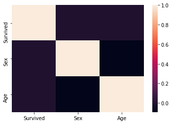

```python
import seaborn as sns

sns.heatmap(df_for_corr.corr())
```